# IBM DS0720EN - Capstone Project

Chris. -- https://github.com/chris-FR-GitHub/EDX-IBM

## Q2 : Should the Department of Housing Preservation and Development of New York City focus on any particular set of boroughs, ZIP codes, or street (where the complaints are severe) for the specific type of complaints you identified in response to Question 1?

For this section, we only take **'HEAT/HOT WATER' & 'HEATING'** type complaints.

```python
# if Folium is not installed by default
# !pip install Folium
```

**NOTE** We uploaded the NYC ZIP code GeoJSON file in the input foolder : **nyc-zip-code-tabulation-areas-polygons.geojson**  
This file is available on the GitHub folder.

### Load the data file and filter it to keep : 'HEAT/HOT WATER' & 'HEATING' complaints

```python
# Import required libs
import pandas as pd
import numpy as np
import matplotlib.pyplot as plt
import seaborn as sns
```

```python
# Load the file in a dataframe
# As suggested in the "Ingest the NYC 311 Dataset" page : Parse the date fields by using the parse_dates option
df_heating = pd.read_csv('./input/NYC_311_Dataset.csv', parse_dates = ['created_date', 'closed_date'])

# merge  'HEAT/HOT WATER' & 'HEATING' type complaints
df_heating['complaint_type'].replace(
    to_replace=['HEAT/HOT WATER', 'HEATING'],
    value='HEATING/HOT WATER',
    inplace=True
)

# Keep only these 2 types
df_heating = df_heating[df_heating['complaint_type'] == 'HEATING/HOT WATER']

df_heating.head(10)
```

|  | created_date | unique_key | complaint_type | incident_zip | incident_address | street_name | address_type | city | resolution_description | borough | latitude | longitude | closed_date | location_type | status |
| --- | --- | --- | --- | --- | --- | --- | --- | --- | --- | --- | --- | --- | --- | --- | --- |
| 0 | 2020-01-28 20:26:11 | 45492325 | HEATING/HOT WATER | 10462.0 | 2040 BRONXDALE AVENUE | BRONXDALE AVENUE | ADDRESS | BRONX | The complaint you filed is a duplicate of a co... | BRONX | 40.850795 | -73.866537 | NaT | RESIDENTIAL BUILDING | Open |
| 2 | 2020-01-28 04:49:03 | 45494360 | HEATING/HOT WATER | 11225.0 | 181 HAWTHORNE STREET | HAWTHORNE STREET | ADDRESS | BROOKLYN | The Department of Housing Preservation and Dev... | BROOKLYN | 40.657592 | -73.954469 | 2020-01-28 21:37:27 | RESIDENTIAL BUILDING | Closed |
| 4 | 2020-01-28 14:10:04 | 45492347 | HEATING/HOT WATER | 10463.0 | 2800 BAILEY AVENUE | BAILEY AVENUE | ADDRESS | BRONX | The complaint you filed is a duplicate of a co... | BRONX | 40.873356 | -73.905554 | NaT | RESIDENTIAL BUILDING | Open |
| 5 | 2020-01-28 08:07:55 | 45492310 | HEATING/HOT WATER | 11225.0 | 1789 BEDFORD AVENUE | BEDFORD AVENUE | ADDRESS | BROOKLYN | The following complaint conditions are still o... | BROOKLYN | 40.662278 | -73.957064 | NaT | RESIDENTIAL BUILDING | Open |
| 6 | 2020-01-28 21:11:02 | 45492265 | HEATING/HOT WATER | 11226.0 | 2815 BEVERLY ROAD | BEVERLY ROAD | ADDRESS | BROOKLYN | The following complaint conditions are still o... | BROOKLYN | 40.645038 | -73.950632 | NaT | RESIDENTIAL BUILDING | Open |
| 7 | 2020-01-28 07:27:16 | 45493379 | HEATING/HOT WATER | 10462.0 | 2040 BRONXDALE AVENUE | BRONXDALE AVENUE | ADDRESS | BRONX | The complaint you filed is a duplicate of a co... | BRONX | 40.850795 | -73.866537 | NaT | RESIDENTIAL BUILDING | Open |
| 8 | 2020-01-28 07:21:15 | 45494446 | HEATING/HOT WATER | 10462.0 | 2040 BRONXDALE AVENUE | BRONXDALE AVENUE | ADDRESS | BRONX | The complaint you filed is a duplicate of a co... | BRONX | 40.850795 | -73.866537 | NaT | RESIDENTIAL BUILDING | Open |
| 12 | 2020-01-28 16:57:34 | 45496537 | HEATING/HOT WATER | 11419.0 | 113-09 101 AVENUE | 101 AVENUE | ADDRESS | South Richmond Hill | The Department of Housing Preservation and Dev... | QUEENS | 40.688594 | -73.830825 | 2020-01-28 21:37:43 | RESIDENTIAL BUILDING | Closed |
| 13 | 2020-01-28 23:24:59 | 45496448 | HEATING/HOT WATER | 10473.0 | 2059 STORY AVENUE | STORY AVENUE | ADDRESS | BRONX | The following complaint conditions are still o... | BRONX | 40.824872 | -73.853925 | NaT | RESIDENTIAL BUILDING | Open |
| 14 | 2020-01-28 20:52:32 | 45496544 | HEATING/HOT WATER | 10009.0 | 121 ST MARKS PLACE | ST MARKS PLACE | ADDRESS | NEW YORK | The complaint you filed is a duplicate of a co... | MANHATTAN | 40.727256 | -73.984471 | NaT | RESIDENTIAL BUILDING | Open |

```python
# Get the dataframe size
df_heating.shape
```

```
(2146129, 15)
```

```python
df_heating['incident_zip'] = df_heating['incident_zip'].astype('Int64')
```

### Check NaN values

```python
# Count NaN values in each column
df_NaN_count = df_heating.isnull().sum(axis = 0)
df_NaN_count = df_NaN_count.to_frame()
df_NaN_count.rename(columns = {list(df_NaN_count)[0]:'Count'}, inplace=True)
df_NaN_count['NaN %'] = df_NaN_count['Count'] / len(df_heating)
df_NaN_count['NaN %'] = df_NaN_count['NaN %'].map(lambda x: "{0:.2f}%".format(x*100))
df_NaN_count
```

|  | Count | NaN % |
| --- | --- | --- |
| created_date | 0 | 0.00% |
| unique_key | 0 | 0.00% |
| complaint_type | 0 | 0.00% |
| incident_zip | 19024 | 0.89% |
| incident_address | 1 | 0.00% |
| street_name | 1 | 0.00% |
| address_type | 17996 | 0.84% |
| city | 18881 | 0.88% |
| resolution_description | 222 | 0.01% |
| borough | 0 | 0.00% |
| latitude | 19020 | 0.89% |
| longitude | 19020 | 0.89% |
| closed_date | 15864 | 0.74% |
| location_type | 0 | 0.00% |
| status | 0 | 0.00% |

No NaN value for the **borough** column and only 1 NaN for the **street_name** column.  
Around 19k NaN records for the **incident_zip** column (less than 0,9%).

### Check number of unique values

#### street_name

```python
df_heating['street_name'].nunique()
```

```
6024
```

#### incident_zip

```python
df_heating['incident_zip'].nunique()
```

```
193
```

#### borough

```python
df_heating['borough'].nunique()
```

```
6
```

```python
#Check distinct complaint_type
df_heating['borough'].unique()
```

```
array(['BRONX', 'BROOKLYN', 'QUEENS', 'MANHATTAN', 'STATEN ISLAND',
       'Unspecified'], dtype=object)
```

Even if there are no NaN in the **borough** column. There is an 'Unspecified' value.

### Count by **street_name**

```python
def getCountAndPercent(col):
    df = pd.concat([col.value_counts(),
                    col.value_counts(normalize=True).mul(100).map(lambda x: "{0:.2f}%".format(x))],
                   axis=1,
                   keys=('Count','Percentage'))
    return df

#get the count and percentage
df_heating_cpls_by_street_name = getCountAndPercent( df_heating['street_name'])
df_heating_cpls_by_street_name.head(10)
```

|  | Count | Percentage |
| --- | --- | --- |
| GRAND CONCOURSE | 37792 | 1.76% |
| BROADWAY | 24467 | 1.14% |
| OCEAN AVENUE | 18676 | 0.87% |
| MORRIS AVENUE | 16385 | 0.76% |
| ARDEN STREET | 15958 | 0.74% |
| ST NICHOLAS AVENUE | 15584 | 0.73% |
| ELMHURST AVENUE | 12333 | 0.57% |
| AMSTERDAM AVENUE | 12274 | 0.57% |
| BOYNTON AVENUE | 11124 | 0.52% |
| DR M L KING JR BOULEVARD | 10407 | 0.48% |

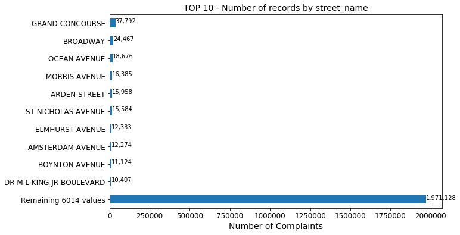

```python
# plot the count
def plotTOP10(df, strTitle):
    # TOP 10 and an OTHER type
    top10_other = df.head(10)
    if len(df) > 10:
        top10_other['Remaining {0} values'.format(len(df) - 10)] = sum(df[10:])

    top10_other.plot(kind='barh', figsize=(10, 6),fontsize=12)
    plt.xlabel('Number of Complaints',fontsize=14)
    plt.title(strTitle, fontsize=14)
    plt.gca().invert_yaxis()
    [plt.text(v, i, '{:,d}'.format(v)) for i, v in enumerate(top10_other)];
    plt.show()

plotTOP10(df_heating_cpls_by_street_name['Count'], 'TOP 10 - Number of records by street_name')
```

#### The **GRAND CONCOURSE** street has the higher number of complaints : 38k.

### Count by **incident_zip**

```python
#get the count and percentage
df_heating_cpls_by_incident_zip = getCountAndPercent( df_heating['incident_zip'].dropna().astype(str))
df_heating_cpls_by_incident_zip.head(10)
```

|  | Count | Percentage |
| --- | --- | --- |
| 11226 | 68941 | 3.24% |
| 10467 | 65980 | 3.10% |
| 10458 | 65263 | 3.07% |
| 10468 | 58098 | 2.73% |
| 10453 | 57735 | 2.71% |
| 10452 | 49703 | 2.34% |
| 10457 | 46705 | 2.20% |
| 10031 | 44720 | 2.10% |
| 10040 | 44447 | 2.09% |
| 10456 | 43985 | 2.07% |

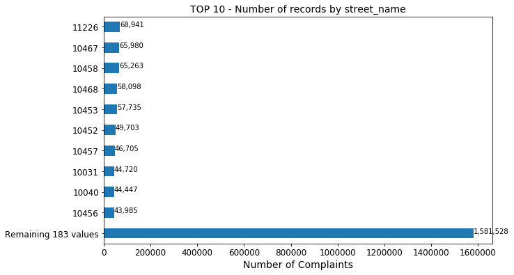

```python
# plot the TOP 10
plotTOP10(df_heating_cpls_by_incident_zip['Count'], 'TOP 10 - Number of records by street_name')
```

#### The **ZIP code : 11226** has the higher number of complaints : 69k.

### Count by **borough**

```python
def getCountAndPercent(col):
    df = pd.concat([col.value_counts(),
                    col.value_counts(normalize=True).mul(100).map(lambda x: "{0:.2f}%".format(x))],
                   axis=1,
                   keys=('Count','Percentage'))
    return df

#get the count and percentage
df_heating_cpls_by_borough = getCountAndPercent( df_heating['borough'])
df_heating_cpls_by_borough.head(10)
```

|  | Count | Percentage |
| --- | --- | --- |
| BRONX | 604848 | 28.18% |
| BROOKLYN | 573883 | 26.74% |
| MANHATTAN | 422452 | 19.68% |
| Unspecified | 282917 | 13.18% |
| QUEENS | 243685 | 11.35% |
| STATEN ISLAND | 18344 | 0.85% |

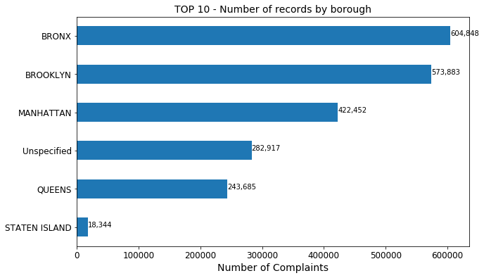

```python
# plot the count
def plotTOP10(df, strTitle):
    # TOP 10 and an OTHER type
    top10_other = df.head(10)
    if len(df) > 10:
        top10_other['Remaining {0} values'.format(len(df) - 10)] = sum(df[10:])

    top10_other.plot(kind='barh', figsize=(10, 6),fontsize=12)
    plt.xlabel('Number of Complaints',fontsize=14)
    plt.title(strTitle, fontsize=14)
    plt.gca().invert_yaxis()
    [plt.text(v, i, '{:,d}'.format(v)) for i, v in enumerate(top10_other)];
    plt.show()

plotTOP10(df_heating_cpls_by_borough['Count'], 'TOP 10 - Number of records by borough')
```

#### The BRONX borough has the higher number of complaints : 604k. BROOKLYN is second : 574k.

Note that the **"Unspecified"** value represents 13% of the values. We may have to try to replace it with the correct borought using the ZIP and address column.

### Count by **ZIP** - **borough**

We can try to check ZIP and borough:

```python
df_heating_cpls_by_incident_zip_bo = df_heating.groupby(['incident_zip', 'borough']).size()
df_heating_cpls_by_incident_zip_bo.head(10)
```

```
incident_zip  borough
10001         MANHATTAN       3327
              Unspecified      813
10002         MANHATTAN      12861
              Unspecified     1621
10003         MANHATTAN       9759
              Unspecified     1159
10004         MANHATTAN        141
              Unspecified       20
10005         MANHATTAN        175
              Unspecified        6
dtype: int64
```

We should be able to replace the 'Unspecified' borough by the ZIP primary borough.

```python
df_heating_cpls_by_incident_zip_bo.sort_values(ascending=False).head(10)
```

```
incident_zip  borough
11226         BROOKLYN     59573
10467         BRONX        57097
10458         BRONX        56883
10468         BRONX        50578
10453         BRONX        49855
10452         BRONX        43210
10457         BRONX        40468
10031         MANHATTAN    39158
10456         BRONX        38007
10040         MANHATTAN    37856
dtype: int64
```

We find the same result than the ZIP code :

- the 1st ZIP code 11226 is in BROOKLYN
- the next 6th ones : 10467, 10458, 10468, 10453, 10452 and 10457 are in the BRONX

```python
# df_zip_borough = df_heating[['incident_zip','borough']].drop_duplicates(['incident_zip','borough'])
df_zip_borough = df_heating.groupby(['incident_zip', 'borough']).size().reset_index()
df_zip_borough_nounspecified = df_zip_borough[df_zip_borough['borough'] != 'Unspecified']
df_zip_borough_nounspecified.shape
```

```
(195, 3)
```

```python
df_zip_borough_nounspecified['incident_zip'].nunique()
```

```
193
```

2 ZIPs have multiple borough... Keep the 1st one...

```python
df_zip_borough_nounspecified=df_zip_borough_nounspecified.sort_values(by=[0], ascending=False).groupby('incident_zip').first().reset_index()
df_zip_borough_nounspecified.rename(columns={'borough':'newborough'}, inplace=True)
df_zip_borough_nounspecified.head(10)
```

|  | incident_zip | newborough | 0 |
| --- | --- | --- | --- |
| 0 | 10001 | MANHATTAN | 3327 |
| 1 | 10002 | MANHATTAN | 12861 |
| 2 | 10003 | MANHATTAN | 9759 |
| 3 | 10004 | MANHATTAN | 141 |
| 4 | 10005 | MANHATTAN | 175 |
| 5 | 10006 | MANHATTAN | 194 |
| 6 | 10007 | MANHATTAN | 214 |
| 7 | 10009 | MANHATTAN | 13228 |
| 8 | 10010 | MANHATTAN | 3863 |
| 9 | 10011 | MANHATTAN | 7324 |

```python
df_zip_borough_nounspecified.shape
```

```
(193, 3)
```

```python
merged_zip_borough = pd.merge(df_zip_borough, df_zip_borough_nounspecified,
                              left_on="incident_zip",
                              right_on="incident_zip", how="left")
merged_zip_borough.rename(columns={'0_x':'Count'}, inplace=True)
merged_zip_borough.head(10)
```

|  | incident_zip | borough | Count | newborough | 0_y |
| --- | --- | --- | --- | --- | --- |
| 0 | 10001 | MANHATTAN | 3327 | MANHATTAN | 3327 |
| 1 | 10001 | Unspecified | 813 | MANHATTAN | 3327 |
| 2 | 10002 | MANHATTAN | 12861 | MANHATTAN | 12861 |
| 3 | 10002 | Unspecified | 1621 | MANHATTAN | 12861 |
| 4 | 10003 | MANHATTAN | 9759 | MANHATTAN | 9759 |
| 5 | 10003 | Unspecified | 1159 | MANHATTAN | 9759 |
| 6 | 10004 | MANHATTAN | 141 | MANHATTAN | 141 |
| 7 | 10004 | Unspecified | 20 | MANHATTAN | 141 |
| 8 | 10005 | MANHATTAN | 175 | MANHATTAN | 175 |
| 9 | 10005 | Unspecified | 6 | MANHATTAN | 175 |

```python
merged_zip_borough_count = merged_zip_borough.groupby(['incident_zip', 'newborough'])['Count'].sum().reset_index()
merged_zip_borough_count.sort_values(by=['Count'],ascending=False).head(10)
```

|  | incident_zip | newborough | Count |
| --- | --- | --- | --- |
| 126 | 11226 | BROOKLYN | 68941 |
| 81 | 10467 | BRONX | 65980 |
| 72 | 10458 | BRONX | 65263 |
| 82 | 10468 | BRONX | 58098 |
| 67 | 10453 | BRONX | 57735 |
| 66 | 10452 | BRONX | 49703 |
| 71 | 10457 | BRONX | 46705 |
| 28 | 10031 | MANHATTAN | 44720 |
| 37 | 10040 | MANHATTAN | 44447 |
| 70 | 10456 | BRONX | 43985 |

```python
merged_zip_borough_count = merged_zip_borough.groupby(['newborough'])['Count'].sum().reset_index()
merged_zip_borough_count.sort_values(by=['Count'],ascending=False).head(10)
```

|  | newborough | Count |
| --- | --- | --- |
| 0 | BRONX | 691720 |
| 1 | BROOKLYN | 661694 |
| 2 | MANHATTAN | 472667 |
| 3 | QUEENS | 279380 |
| 4 | STATEN ISLAND | 21644 |

Removing the **'Unspecified'** borough value and replacing it by the ones of the ZIP codes does not change the results.

## Trial: Folium map - ZIP code level

We uploaded the NYC ZIP code GeoJSON file in the input foolder : **nyc-zip-code-tabulation-areas-polygons.geojson**

```python
import folium
import json
from folium import plugins
```

```python
countByZIP = df_heating.dropna()['incident_zip'].astype('Int64').value_counts()

#initialize an empty dataframe to store this new data
numComplaintsByZip = pd.DataFrame()

#populate the new dataframe with a 'zipcode' column and a 'numComplaints' column
numComplaintsByZip['zipcode'] = [str(i) for i in countByZIP.index]
numComplaintsByZip['numComplaints'] = countByZIP.values

numComplaintsByZip.head(10)
```

|  | zipcode | numComplaints |
| --- | --- | --- |
| 0 | 11226 | 68674 |
| 1 | 10467 | 65695 |
| 2 | 10458 | 64829 |
| 3 | 10468 | 57898 |
| 4 | 10453 | 57357 |
| 5 | 10452 | 49452 |
| 6 | 10457 | 46466 |
| 7 | 10040 | 44249 |
| 8 | 10031 | 43907 |
| 9 | 10456 | 43666 |

```python
#initialize the NYC map
nycMap = folium.Map(location=[40.693943, -73.985880], default_zoom_start=10)

# creata a new Choropleth class object and add it to the map
folium.Choropleth(geo_data='input/nyc-zip-code-tabulation-areas-polygons.geojson',
                  data=numComplaintsByZip,
                  columns=['zipcode', 'numComplaints'],
                  key_on='feature.properties.postalCode', fill_color='YlGn',
                  fill_opacity=0.7,
                  line_opacity=0.2,
                  legend_name='Number of Coplaints by ZIP code').add_to(nycMap)

# draw the map
nycMap
```

[interactive chart not shown]

## Q2 Conclusion

- The **BRONX** is the borough which has the most 'HEAT/HOT WATER' & 'HEATING' complaints and **BROOKLYN** is the second one.
- **GRAND CONCOURSE** is the street which has the most 'HEAT/HOT WATER' & 'HEATING' complaints.
- **11226** (BROOKLYN borough) is the Zip Code which has the most 'HEAT/HOT WATER' & 'HEATING' complaints.